# Figure 3 and S5 processing script

Hyunwoo Cho

2022-10-03

### Preparing the data

Download the sequence data from SRA and convert to `FASTQ` using this script.

```bash
prefetch SRR111111xx
fastq-dump SRR111111xx.sra --split-files --gzip -O SRR111111xx/
```

The `MD5` sum of the `fastq` files is attached below.

```bash
md5sum */*.fastq.gz
c26b8147e6aee03d7f0ccfd0d949faa0  Sample_E223D0P531WT1_IGO_11351_C_1/E223D0P531WT1_IGO_11351_C_1_S12_L001_R1_001.fastq.gz
9271783197d8b229f1f6dacd9217e784  Sample_E223D0P531WT1_IGO_11351_C_1/E223D0P531WT1_IGO_11351_C_1_S12_L001_R2_001.fastq.gz
dc1475cfd4cfa66d655b929e463f8b20  Sample_E223D0P531WT1_IGO_11351_C_1/E223D0P531WT1_IGO_11351_C_1_S12_L002_R1_001.fastq.gz
0d3c5fbf2c98a83b564b8d2850db4650  Sample_E223D0P531WT1_IGO_11351_C_1/E223D0P531WT1_IGO_11351_C_1_S12_L002_R2_001.fastq.gz
c9479611bd09e0770ab361e8198dfd41  Sample_E223D0P531WT2_IGO_11351_C_2/E223D0P531WT2_IGO_11351_C_2_S13_L001_R1_001.fastq.gz
5f7fe46ea95982a00fc4b4df30eac18e  Sample_E223D0P531WT2_IGO_11351_C_2/E223D0P531WT2_IGO_11351_C_2_S13_L001_R2_001.fastq.gz
b3604dc08fd776f2cdea34e96b19e465  Sample_E223D0P531WT2_IGO_11351_C_2/E223D0P531WT2_IGO_11351_C_2_S13_L002_R1_001.fastq.gz
def2c5c56286f6148efd0f286c1f6afd  Sample_E223D0P531WT2_IGO_11351_C_2/E223D0P531WT2_IGO_11351_C_2_S13_L002_R2_001.fastq.gz
435eae5599b548b55df8a7792661cf01  Sample_E223D1CULTUREP53WT1_IGO_11351_C_5/E223D1CULTUREP53WT1_IGO_11351_C_5_S16_L001_R1_001.fastq.gz
b1e8cf43d7ca63753fc8ae22bcdd99dc  Sample_E223D1CULTUREP53WT1_IGO_11351_C_5/E223D1CULTUREP53WT1_IGO_11351_C_5_S16_L001_R2_001.fastq.gz
3089b20b2d14e40520095fc19a8332d2  Sample_E223D1CULTUREP53WT1_IGO_11351_C_5/E223D1CULTUREP53WT1_IGO_11351_C_5_S16_L002_R1_001.fastq.gz
f65ca903729f727b924920900c1817df  Sample_E223D1CULTUREP53WT1_IGO_11351_C_5/E223D1CULTUREP53WT1_IGO_11351_C_5_S16_L002_R2_001.fastq.gz
316e14c36fb4756c2801f6cd4ae4a9b5  Sample_E223D1CULTUREP53WT2_IGO_11351_C_6/E223D1CULTUREP53WT2_IGO_11351_C_6_S17_L001_R1_001.fastq.gz
b1cc2dd04fe7f3587025e93c8789504a  Sample_E223D1CULTUREP53WT2_IGO_11351_C_6/E223D1CULTUREP53WT2_IGO_11351_C_6_S17_L001_R2_001.fastq.gz
c0c68c3935a72ab26248ab7d58195e89  Sample_E223D1CULTUREP53WT2_IGO_11351_C_6/E223D1CULTUREP53WT2_IGO_11351_C_6_S17_L002_R1_001.fastq.gz
58132b593bd16b88ede7615e5ba3c23e  Sample_E223D1CULTUREP53WT2_IGO_11351_C_6/E223D1CULTUREP53WT2_IGO_11351_C_6_S17_L002_R2_001.fastq.gz
09bcae95b480c320b353f4f7aa2fe986  Sample_E223D1GRAFTP53WT1_IGO_11351_C_9/E223D1GRAFTP53WT1_IGO_11351_C_9_S20_L001_R1_001.fastq.gz
8a99885cc8580660669adda688b0a226  Sample_E223D1GRAFTP53WT1_IGO_11351_C_9/E223D1GRAFTP53WT1_IGO_11351_C_9_S20_L001_R2_001.fastq.gz
d98305de166e551069794e7e97d86d4a  Sample_E223D1GRAFTP53WT1_IGO_11351_C_9/E223D1GRAFTP53WT1_IGO_11351_C_9_S20_L002_R1_001.fastq.gz
ebdffbe7a65eec434f85e3f4f8ccfb38  Sample_E223D1GRAFTP53WT1_IGO_11351_C_9/E223D1GRAFTP53WT1_IGO_11351_C_9_S20_L002_R2_001.fastq.gz
5a60b4e7316edcc2dcf08d6c3aa64a1e  Sample_E223D1GRAFTP53WT2_IGO_11351_C_10/E223D1GRAFTP53WT2_IGO_11351_C_10_S11_L001_R1_001.fastq.gz
affde9be3fc59f9c06398a3c915802e2  Sample_E223D1GRAFTP53WT2_IGO_11351_C_10/E223D1GRAFTP53WT2_IGO_11351_C_10_S11_L001_R2_001.fastq.gz
9371d40e457f2d0f7b7e7f6261d33e55  Sample_E223D1GRAFTP53WT2_IGO_11351_C_10/E223D1GRAFTP53WT2_IGO_11351_C_10_S11_L002_R1_001.fastq.gz
1989d64bdd173f8141a5369e3e73cc19  Sample_E223D1GRAFTP53WT2_IGO_11351_C_10/E223D1GRAFTP53WT2_IGO_11351_C_10_S11_L002_R2_001.fastq.gz
```

### Run alignment using this reproducible script:

A human hg19 reference genome can be accessed at Illumina iGenomes page (https://support.illumina.com/sequencing/sequencing_software/igenome.html).

Start the two-pass alignment here.

First pass.

```bash
wget -c https://ftp.ebi.ac.uk/pub/databases/gencode/Gencode_human/release_38/GRCh37_mapping/gencode.v38lift37.annotation.gtf.gz
gunzip -c gencode.v38lift37.annotation.gtf.gz

STAR --version
2.5.0a

STAR --runMode alignReads --runThreadN 16 \
  --genomeDir /directory/iGenomes/Homo_sapiens/UCSC/hg19/Sequence/WholeGenomeFasta \
  --limitBAMsortRAM 10000000000 --outSAMstrandField intronMotif --outSAMattrRGline ID:{} PL:ILLUMINA SM:{} \
  --readFilesIn \
    E223D0P531WT1_IGO_11351_C_1_S12_L001_trimmed_R1.fastq.gz,E223D0P531WT1_IGO_11351_C_1_S12_L002_trimmed_R1.fastq.gz \
    E223D0P531WT1_IGO_11351_C_1_S12_L001_trimmed_R2.fastq.gz,E223D0P531WT1_IGO_11351_C_1_S12_L002_trimmed_R2.fastq.gz \
  --readFilesCommand zcat --outFileNamePrefix E223D0P531WT1_IGO_11351_C_1_S12/E223D0P531WT1_IGO_11351_C_1_S12. \
  --outFilterIntronMotifs RemoveNoncanonicalUnannotated --outSAMattributes All --outSAMunmapped Within \
  --outSAMtype BAM Unsorted --outBAMcompression -1 --outFilterMultimapNmax 1 --outFilterMismatchNoverLmax 0.06 \
  --outFilterMatchNmin 30 --outSJfilterOverhangMin 30 10 10 10 --seedSearchStartLmax 30 --alignIntronMin 20 \
  --alignIntronMax 20000 --alignEndsType Local

# rm -i E223D0P531WT1_IGO_11351_C_1_S12/*.bam
```

Second pass.

```bash
# filter sjdb.
cat E223D0P531WT1_IGO_11351_C_1_S12/*SJ.out.tab | awk '($1 != "chrM" && $5 > 0 && $6 == 0 && $7 > 2)' | cut -f1-6 | sort | uniq > SJ.filtered.tab

# genome generate
STAR --runMode genomeGenerate --runThreadN 16 --genomeDir `pwd` \
  --genomeFastaFiles /directory/iGenomes/Homo_sapiens/UCSC/hg19/Sequence/WholeGenomeFasta/genome.fa \
  --sjdbGTFfile gencode.v38lift37.annotation.gtf --sjdbOverhang 100 --sjdbFileChrStartEnd SJ.filtered.tab

# alignment
STAR --runMode alignReads --runThreadN 16 \
  --genomeDir `pwd` \
  --limitBAMsortRAM 10000000000 --outSAMstrandField intronMotif --outSAMattrRGline ID:{} PL:ILLUMINA SM:{} \
  --readFilesIn \
    E223D0P531WT1_IGO_11351_C_1_S12_L001_trimmed_R1.fastq.gz,E223D0P531WT1_IGO_11351_C_1_S12_L002_trimmed_R1.fastq.gz \
    E223D0P531WT1_IGO_11351_C_1_S12_L001_trimmed_R2.fastq.gz,E223D0P531WT1_IGO_11351_C_1_S12_L002_trimmed_R2.fastq.gz \
  --readFilesCommand zcat --outFileNamePrefix E223D0P531WT1_IGO_11351_C_1_S12/E223D0P531WT1_IGO_11351_C_1_S12.Twopass. \
  --outFilterIntronMotifs RemoveNoncanonicalUnannotated --outSAMattributes All --outSAMunmapped Within \
  --outSAMtype BAM SortedByCoordinate --outBAMcompression -1 --outFilterMultimapNmax 1 \
  --outFilterMismatchNoverLmax 0.06 --outFilterMatchNmin 30 --outSJfilterOverhangMin 30 10 10 10 \
  --seedSearchStartLmax 30 --alignIntronMin 20 --alignIntronMax 20000 --alignEndsType Local

htseq-count --version
# 1.99.2
htseq-count -f bam -r pos -s no -t CDS -i gene_name -m union E223D0P531WT1_IGO_11351_C_1_S12.Twopass.bam gencode.v38lift37.annotation.gtf > Proj_11351_C_s_E223D0P531WT1-htseq-count-matrix.txt
```

The `MD5` sum of the gene quantification files is attached below.

```bash
md5sum *-htseq-count-matrix.txt
79fa5a164ee02c16c59bef06697a9d1c  Proj_11351_C_s_E223D0P531WT1-htseq-count-matrix.txt
cc4d5f75f9625560a2e575cda67249e2  Proj_11351_C_s_E223D0P531WT2-htseq-count-matrix.txt
049542fc33223c02bc6d095274f66f25  Proj_11351_C_s_E223D1CULTUREP53WT1-htseq-count-matrix.txt
96bc008e91c147f2747977a4e82a5401  Proj_11351_C_s_E223D1CULTUREP53WT2-htseq-count-matrix.txt
d24d8c218f8f2d486ca771d5df4e4198  Proj_11351_C_s_E223D1GRAFTP53WT1-htseq-count-matrix.txt
0b8ab35617d9cb5ddea79e6e37e2acda  Proj_11351_C_s_E223D1GRAFTP53WT2-htseq-count-matrix.txt
```

```r
library(data.table)
library(rtracklayer)
library(DESeq2)
library(magrittr)
```

Load the gene quantification results and make a `DESeq2` object.

```r
fn = dir(path="internal-data", pattern="*-htseq-count-matrix.txt", recursive=T, full.names=T)
fn %>% file.exists
```

```
## [1] TRUE TRUE TRUE TRUE TRUE TRUE
```

```r
mySampleName = gsub("Proj_11351_C_s_E223", "", gsub("-htseq.*", "", basename(fn)))
mySampleTable = data.frame(sampleName=mySampleName, fileName=fn, condition=factor(c("D0", "D0", "D1Culture", "D1Culture", "D1Graft", "D1Graft"), levels=c("D0", "D1Culture", "D1Graft")))

DESeq2Obj = DESeqDataSetFromHTSeqCount(sampleTable=mySampleTable, directory=".", design= ~ condition)
DESeq2Obj %<>% DESeq
DESeq2Obj.vst = varianceStabilizingTransformation(DESeq2Obj)
dim(DESeq2Obj)
```

```
## [1] 20492     6
```

### Figure 3A

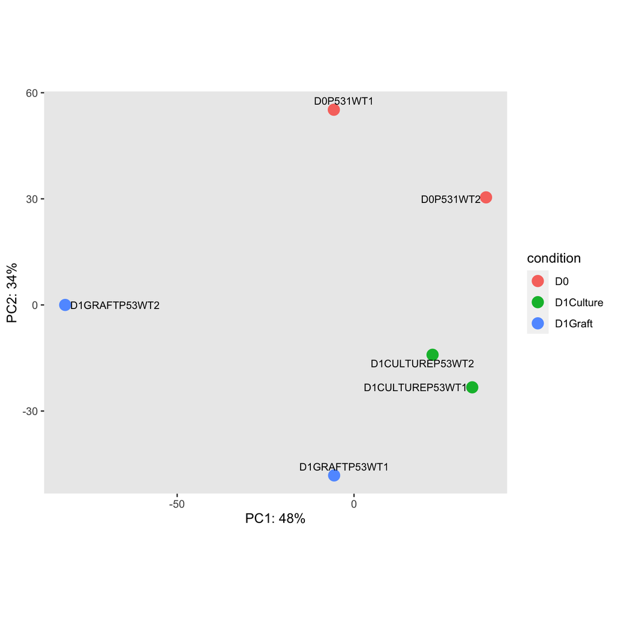

```r
p1 = plotPCA(DESeq2Obj.vst, ntop=3000, intgroup="condition", returnData=T)

library(ggplot2)
library(ggrepel)
percentVar = round(100 * attr(p1, "percentVar"))
ggplot() + geom_point(data=p1, aes(PC1, PC2, color=condition), size=4.0) +
  xlab(paste0("PC1: ", percentVar[1], "%")) + ylab(paste0("PC2: ", percentVar[2], "%")) + coord_fixed() +
  theme(panel.grid=element_blank()) +
  geom_text_repel(data=p1, aes(PC1, PC2, label=row.names(p1)), size=3, max.overlaps=30, segment.alpha=0.1, box.padding=0.2, point.padding=0.20)
```

Note that the ellipses in the paper were added manually.

```r
p1
```

```
##                        PC1          PC2     group condition            name
## D0P531WT1        -5.703104  55.19221171        D0        D0       D0P531WT1
## D0P531WT2        37.338385  30.41462514        D0        D0       D0P531WT2
## D1CULTUREP53WT1  33.434946 -23.29862985 D1Culture D1Culture D1CULTUREP53WT1
## D1CULTUREP53WT2  22.213052 -14.09438278 D1Culture D1Culture D1CULTUREP53WT2
## D1GRAFTP53WT1    -5.617410 -48.20902755   D1Graft   D1Graft   D1GRAFTP53WT1
## D1GRAFTP53WT2   -81.665868  -0.00479668   D1Graft   D1Graft   D1GRAFTP53WT2
```

### Figure S5A

```r
ntop.3000.selector = rowVars(assay(DESeq2Obj.vst)) %>% order(decreasing=T) %>% head(3000)

library(NMF)
library(amap)

row.hclust = hcluster(dist(t(assay(DESeq2Obj.vst)[ntop.3000.selector, ])), method="euclidean", link="single")
row.hclust.d = as.dendrogram(row.hclust)
labels(row.hclust.d)
```

```
## [1] "D1GRAFTP53WT2"   "D1GRAFTP53WT1"   "D1CULTUREP53WT1" "D1CULTUREP53WT2"
## [5] "D0P531WT1"       "D0P531WT2"
```

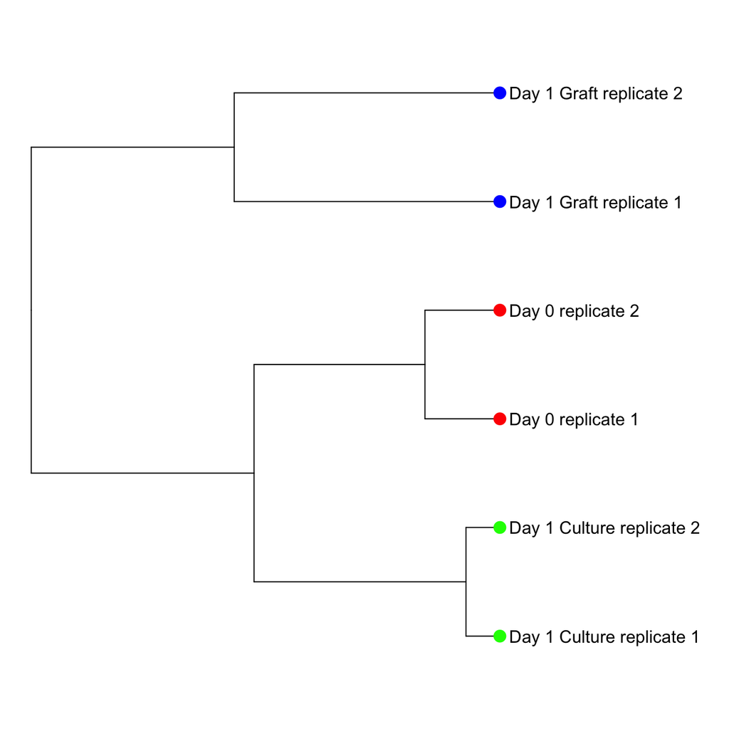

```r
# normalized DESeq2 counts, log2 transform, top 3000 genes, correlation metric, ward linkage
row.hclust.all = hcluster(dist(t(log2(counts(DESeq2Obj, normalized=T) + 1)[ntop.3000.selector, ])), method="correlation", link="ward")

library(dendextend)
row.hclust.all.d = as.dendrogram(row.hclust.all)
row.hclust.all.d = row.hclust.all.d %>% set("labels", c("Day 1 Culture replicate 1", "Day 1 Culture replicate 2", "Day 0 replicate 1", "Day 0 replicate 2", "Day 1 Graft replicate 1", "Day 1 Graft replicate 2")) %>% set("leaves_pch", 19) %>% set("leaves_cex", 1.5) %>% set("leaves_col", c("green", "green", "red", "red", "blue", "blue"))
par(mar=c(0.6, 0.6, 0.6, 10.1))
plot(row.hclust.all.d, sub="", xlab="", yaxt="n", horiz=T)
```

### Figure 3B

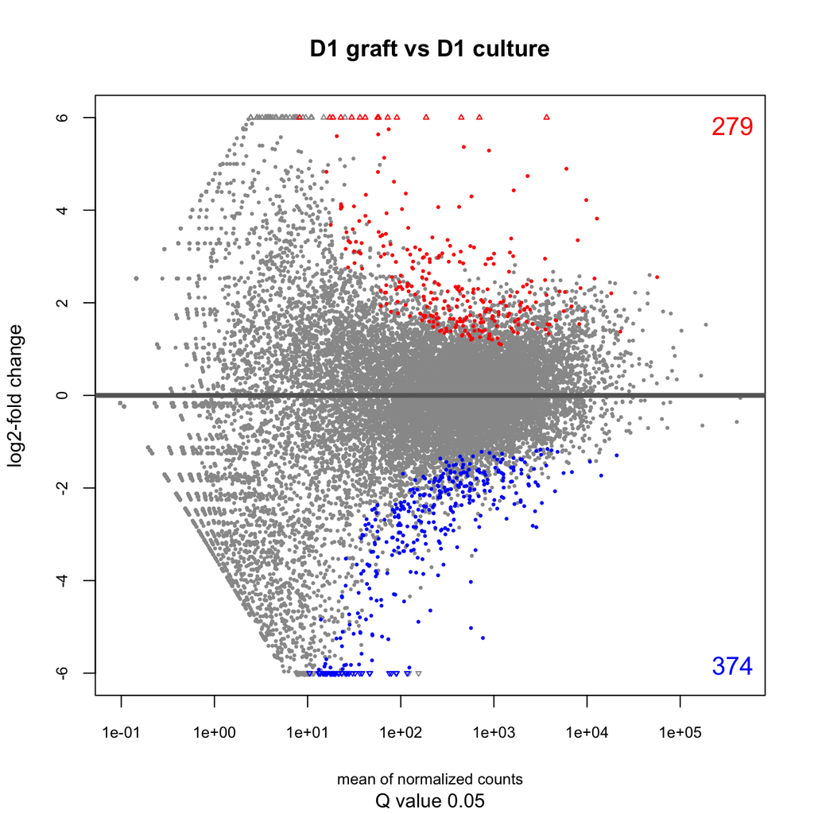

```r
diffExprLst.list = list(
  D0.D1Culture=results(DESeq2Obj, contrast=c("condition", "D1Culture", "D0"), alpha=0.05),
  D0.D1Graft=results(DESeq2Obj, contrast=c("condition", "D1Graft", "D0"), alpha=0.05),
  D1Culture.D1Graft=results(DESeq2Obj, contrast=c("condition", "D1Graft", "D1Culture"), alpha=0.05)
)
for (j in 1:length(diffExprLst.list)) {
  diffExprLst.list[[j]]$padj[is.na(diffExprLst.list[[j]]$padj)] = 1.0
}

p1 = plotMA(diffExprLst.list[[3]], alpha=0.05, returnData=T)
plotMA(diffExprLst.list[[3]], alpha=0.05, main="D1 graft vs D1 culture", sub="Q value 0.05", xlab="", ylim=c(-6.0, +6.0), ylab="log2-fold change", cex.axis=0.80, colSig=NA)
points(pmin(lfc, +6.0) ~ mean, data=subset(p1, isDE & lfc > 0), col="red", pch=ifelse(lfc >= +6.0, 2, 20), cex=0.45)
points(pmax(lfc, -6.0) ~ mean, data=subset(p1, isDE & lfc < 0), col="blue", pch=ifelse(lfc <= -6.0, 6, 20), cex=0.45)
title(xlab="mean of normalized counts", cex.lab=0.80)
legend("topright", inset=c(0, 0), legend=sum(diffExprLst.list[[3]]$padj <= 0.05 & diffExprLst.list[[3]]$log2FoldChange >= 0), bty="n", cex=1.30, text.col="red")
legend("bottomright", inset=c(0, 0), legend=sum(diffExprLst.list[[3]]$padj <= 0.05 & diffExprLst.list[[3]]$log2FoldChange < 0), bty="n", cex=1.30, text.col="blue")
```

### Figure 3C

hallmark markers dotplot on D1 culture -> D1 graft, significantly up

```r
library(msigdbr)
# The latest version of CRAN's msigdbr is 7.5.1.
packageVersion("msigdbr")
```

```
## [1] '7.5.1'
```

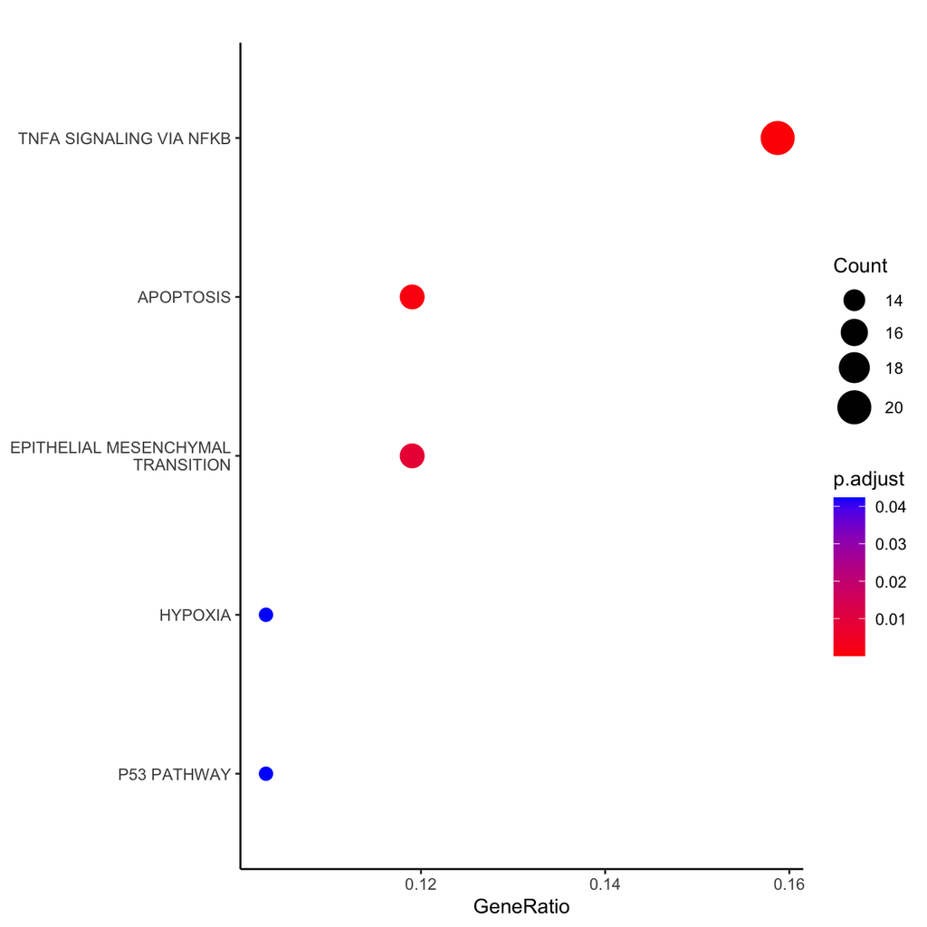

```r
h_gene_sets = msigdbr(species="human", category="H")
h_gene_sets$gs_name = gsub("^HALLMARK_", "", h_gene_sets$gs_name)

library(dplyr)
library(clusterProfiler)
msigdbr_t2g = h_gene_sets %>% dplyr::distinct(gs_name, gene_symbol) %>% as.data.frame()
hallmark.df.3.up = enricher(gene=rownames(subset(diffExprLst.list[[3]], log2FoldChange >= 0 & padj <= 0.05)), TERM2GENE=msigdbr_t2g)

dotplot(hallmark.df.3.up, showCategory=30) + theme_classic()
```

### Figure S5B

hallmark markers dotplot on D1 culture -> D1 graft, significantly down

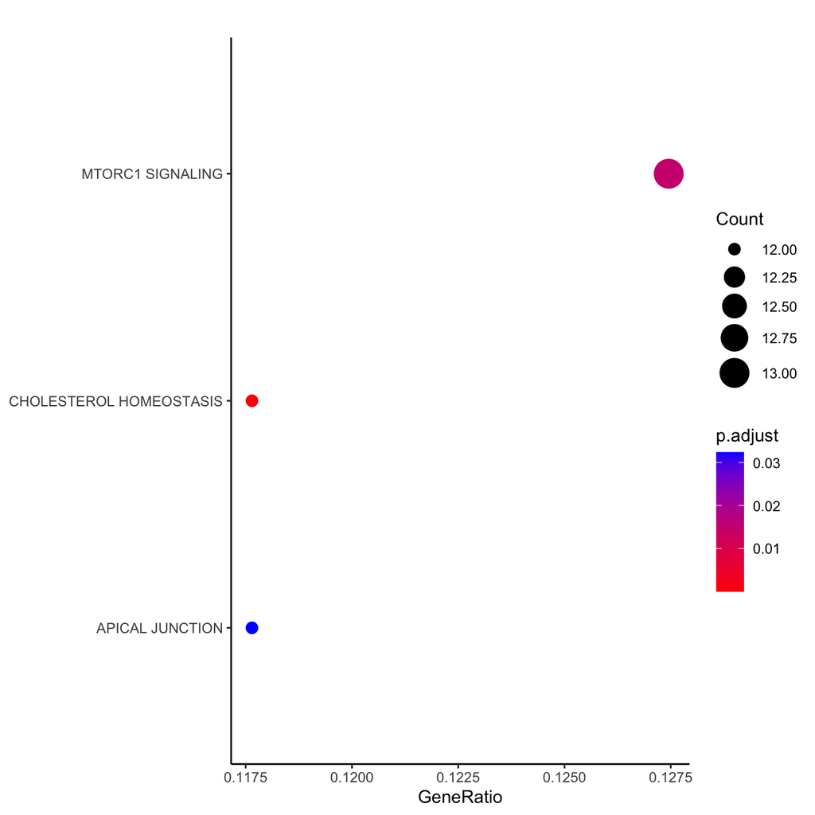

```r
hallmark.df.3.down = enricher(gene=rownames(subset(diffExprLst.list[[3]], log2FoldChange < 0 & padj <= 0.05)), TERM2GENE=msigdbr_t2g)

dotplot(hallmark.df.3.down, showCategory=30) + theme_classic()
```

### Figure S5C

Heat map of GO terms belonging in the GO term (response to tumor necrosis factor)

```r
go.term = "GO:0034612" # (response to tumor necrosis factor)

library(AnnotationDbi)
library(org.Hs.eg.db)
# The latest version of org.Hs.eg.db is 3.15.
# The publication used version 3.13 of org.Hs.eg.db.
packageVersion("org.Hs.eg.db")
```

```
## [1] '3.15.0'
```

```r
go_allegs_object = as.list(org.Hs.egGO2ALLEGS)
# Difference between org.Hs.egGO2EG and org.Hs.eg.GO2ALLEGS
# ALLEGS finds genes that are associated up to child nodes.

entrez.fig.s5c = go_allegs_object$`GO:0034612` %>% unique
symbols.figs.s5c = AnnotationDbi::select(org.Hs.eg.db, keys=entrez.fig.s5c, columns=c("ENTREZID", "SYMBOL"), keytype="ENTREZID")
length(symbols.figs.s5c$SYMBOL)
```

```
## [1] 249
```

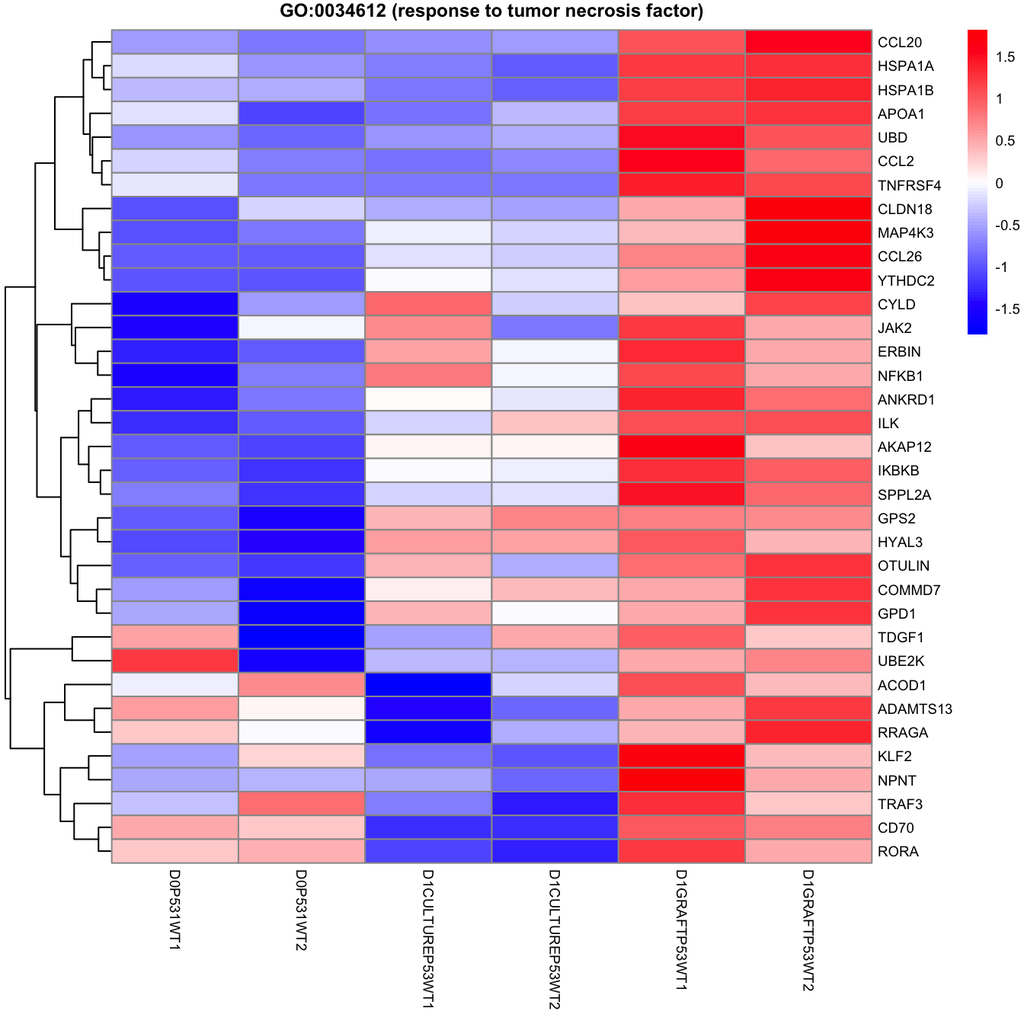

```r
library(pheatmap)

heatmap.input.withvar = assay(DESeq2Obj.vst)[rowVars(counts(DESeq2Obj)) > 0, ]
heatmap.gsea.withvar.1 = pheatmap:::scale_rows(heatmap.input.withvar[rownames(heatmap.input.withvar) %in% symbols.figs.s5c$SYMBOL, ] %>% as.matrix)

# Placed some cutoff on gene expression, on day 1 graft replicates 1 and 2.
gsea.56up.genes.list = rownames(heatmap.gsea.withvar.1[heatmap.gsea.withvar.1[, 5] >= 0.3 & heatmap.gsea.withvar.1[, 6] >= 0.3, ])

pheatmap(heatmap.input.withvar[rownames(heatmap.input.withvar) %in% (gsea.56up.genes.list %>% unique), ] %>% as.matrix, scale="row", main="GO:0034612 (response to tumor necrosis factor)", color=colorRampPalette(c("blue", "white", "red"))(100), cluster_rows=T, cluster_distance_rows="euclidean", cluster_cols=F, show_rownames=T, fontsize=7)
```

### Figure 3D

GSEA using gseaplot2 of enrichplot

This part is not reproducible. Especially the P value part. Saving the result is recommended.

```r
# GSEA using gseaplot2
gene.list.for.gsea = diffExprLst.list[[3]]$log2FoldChange
names(gene.list.for.gsea) = rownames(diffExprLst.list[[3]])
gene.list.for.gsea = na.omit(gene.list.for.gsea)
gene.list.for.gsea = sort(gene.list.for.gsea, decreasing=T)

gse = gseGO(gene.list.for.gsea, OrgDb=org.Hs.eg.db, keyType="SYMBOL", ont="BP", pvalueCutoff=1.0)
# this part is not reproducible. Saving the result is recommended.
dim(gse)
```

```
## [1] 6192   11
```

```r
# GSEA plot using gseaplot2
j = grep("tumor necro", gse$Description)[gse[grep("tumor necro", gse$Description), ]$p.adjust %>% which.min]
message(j)

gse[j, c("ID", "Description", "NES", "p.adjust")]
```

```
##                    ID                       Description      NES   p.adjust
## GO:0034612 GO:0034612 response to tumor necrosis factor 1.421443 0.09425935
```

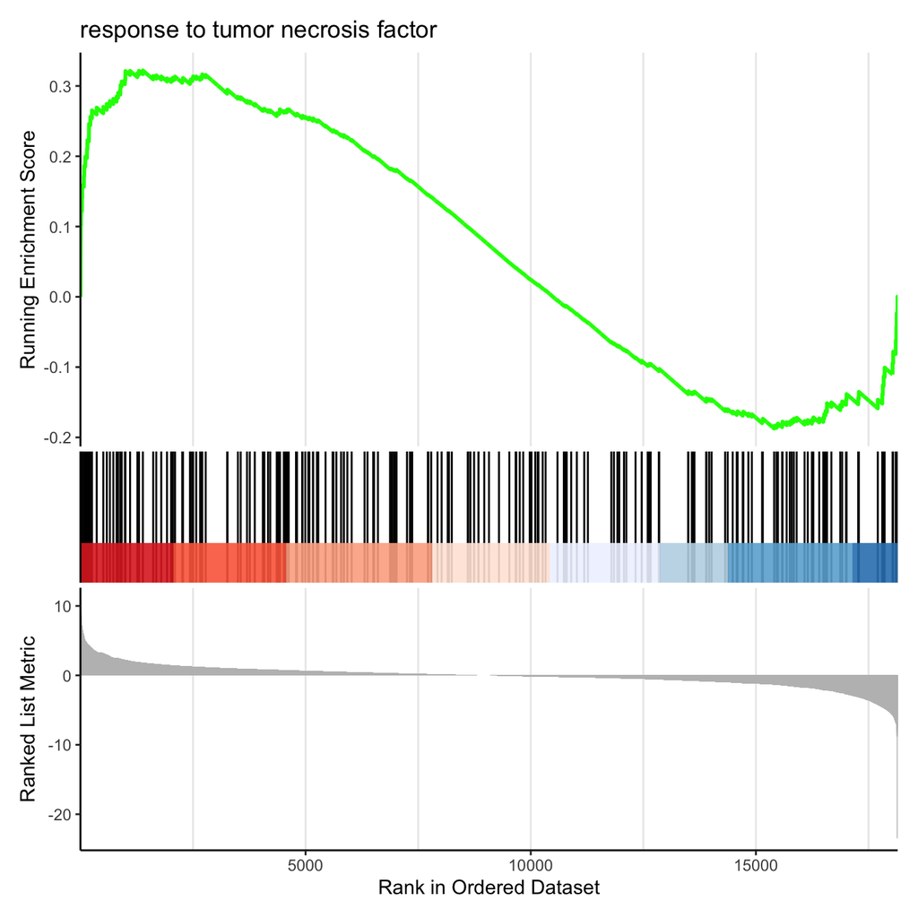

```r
library(enrichplot)
gseaplot2(gse, title=gse$Description[j], geneSetID=j)
```